# Diego Dias_Análise de dados Abertos do Datario

- Autores: Diego Dias.
- Professor: José Viterbo .
- Disciplina: Sistema de Governo Eletrônico.
- Curso Pós-graduação em Computação

### Prefácio:

```
O relatório tem como objetivo demonstrar análise de dados extraindo da plataformas Datario e OpenDataSUS que é vinculado a prefeitura do Rio de Janeiro e Governo Federal, o foco deste trabalho é obtenção de dados de óbitos de Covid-19 que estão registrados no sistemas e-SUS VE, SIVEP Gripe para análise e comparação junto ao paniel Rio Covid-19 e futuro melhoramento da interfaces do Dasboard.
```

### Campos disponíveis:(SOCIODEMOGRÁFICOS)

- classificação_final - mostra a classificação dos casos.Casos confirmados são marcados como "CONFIRMADOS.
- dt_notific:data em que foi feita a notificação do caso, em formato mm/dd/aa.
- dt_inicio_sintomas:data relatada do início dos sintomas, em formato mm/dd/aa.
- bairro_resid_estadia: bairro de resídência ou estadia do paciente usando a lista oficial de bairros do município do Rio de Janeiro.
- ap_residencia_estadia: Área de Planejamento em Saúde correspondente ao bairro de residência ou estadia do paciente.
- sexo:sexo do paciente, podendo ser M=masculino; F =feminino; ou N/D = sem informação.
- faixa etaria: faixa etária em que se encontra o paciente.
- evolução: evolução do caso, podendo ser ativo, óbito ou recuperado.
- dt_evolucao:data em que ocorreu a evolução do quadro, podendo ser a data de óbito ou a data de alta/cura, em formato mm/dd/aa.
- raca_cor: raça/cor do paciente.
- Data atualização: data a que se referem os dados, em formato mm/dd/aa.
- sistema: sistema de origem do registro, podendo ser e-SUS para os casos leves e SIVEP-Gripe para os casos de internação e óbitos.

### Campos disponíveis:(CEP)

- dt_notific:data em que foi feita a notificação do caso.
- dt inicio sintomas: datarelatada do início dos sintomas.
- bairro_resid_estadia:bairro de residência ou estadia do paciente usandoa lista oficial de bairros do município do Rio de Janeiro.
- ap_residencia_estadia:Área de Planejamento em Saúde correspondente ao bairro de residência ou estadia ou estadia do paciente.
- sexo: sexo do paciente, odendo ser M= masculino; F=feminino; ou N/D=sem informação.
- evolução do caso, podendo ser ativo, óbito ou recuperado.
- cep:CEP: do endereço informado na notifcação.

### 1-SUMÁRIO:

- 1- Tabelas de dados.
- 2 - Visualizandos os dados.
- 3 - Tomada de decisão.
- 4 -Conclusão
- 5- Referências.

```python
import pandas as pd
import numpy as np
from IPython.display import Image
```

```python
df = pd.read_csv('db_PainelRioCovid.csv', encoding = 'cp1252', skiprows = 11, sep = ';')
```

### SOCIODEMOGRÁFICO

```python
df.head()
```

|  | CONFIRMADO | 08/27/20 | 08/17/20 | CAVALCANTE | 3.3 | M | De 60 a 69 | OBITO | 08/27/20.1 | Branca | 04/13/21 | SIVEP |
| --- | --- | --- | --- | --- | --- | --- | --- | --- | --- | --- | --- | --- |
| 0 | CONFIRMADO | 01/09/21 | 12/30/20 | TIJUCA | 2.2 | M | De 80 a 89 | OBITO | 02/02/21 | Branca | 04/13/21 | SIVEP |
| 1 | CONFIRMADO | 12/08/20 | 12/01/20 | PILARES | 3.2 | M | De 80 a 89 | OBITO | 01/14/21 | Parda | 04/13/21 | SIVEP |
| 2 | CONFIRMADO | 05/12/20 | 04/26/20 | SANTISSIMO | 5.2 | F | De 60 a 69 | OBITO | 05/13/20 | Parda | 04/13/21 | SIVEP |
| 3 | CONFIRMADO | 11/01/20 | 10/30/20 | CAVALCANTE | 3.3 | M | De 90 a 99 | OBITO | 11/11/20 | Branca | 04/13/21 | SIVEP |
| 4 | CONFIRMADO | 05/18/20 | 05/13/20 | CAMPO GRANDE | 5.2 | M | De 70 a 79 | OBITO | 05/18/20 | Parda | 04/13/21 | SIVEP |

### CEP

```python
df= pd.read_csv('Dados_CEP_MRJ_covid_19.csv', encoding ='cp1252', skiprows =9, sep=';')
```

```python
df.head()
```

|  | 09/01/2021 | 30/12/2020 | TIJUCA | 2.2 | OBITO | 02/02/2021 | 20511190 | 13/04/2021 |
| --- | --- | --- | --- | --- | --- | --- | --- | --- |
| 0 | 08/12/2020 | 01/12/2020 | PILARES | 3.2 | OBITO | 14/01/2021 | 20760620 | 13/04/2021 |
| 1 | 12/05/2020 | 26/04/2020 | SANTISSIMO | 5.2 | OBITO | 13/05/2020 | 23094140 | 13/04/2021 |
| 2 | 01/11/2020 | 30/10/2020 | CAVALCANTE | 3.3 | OBITO | 11/11/2020 | 21370350 | 13/04/2021 |
| 3 | 21/04/2020 | 21/04/2020 | SANTA CRUZ | 5.3 | OBITO | 27/04/2020 | 23515680 | 13/04/2021 |
| 4 | 19/01/2021 | 03/01/2021 | GAMBOA | 1.0 | OBITO | 25/01/2021 | 20221010 | 13/04/2021 |

### Painel SOCIODEMOGRÁFICO.

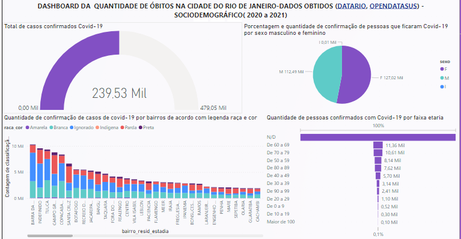

```python
Image('dashboard.png')
```

### Painel CEP:

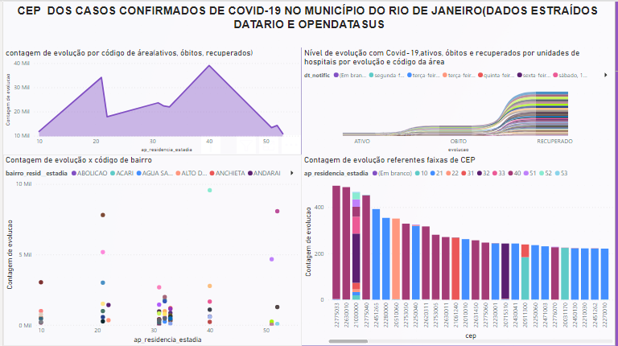

```python
Image("2021-04-17_14-31-43.png")
```

### 3 - Tomada de decisão.

```
As medidas  que podem ser tomada diante das informações obtidos através dos dados são:
    -adotar isolamentos dos bairros que estão apresentando alto indice de covid-19.
    - deslocar mais insumos para hospitais que tem alto de covid-19.
    - alerta as pessoas que  vão para este lugares.
    -flexionar horário de funcionamento de lojas,shopping.
```

### Conclusão:

Os dados ser tornaram imprescindível para organizações privadas e públicos, principalmente para governo que pode toma decisões diante as informações extraindas de bandos de próprio governo. Concluímos que os dados analisados do banco de dados e-SUS e SIVEP-Gripe permitiram mapear os bairros com maior índice de infecção de covid-19, além disso percebemos os locais mais mortes e recuperados.Também conseguirmos descobrir faixas etarias e bairros onde índice é grande.

### REFERÊNCIAS:

[1]-Dados abertos da saúde governo federal. https://opendatasus.saude.gov.br/dataset/bd-srag-2021 .Acesso 15/04/2021.

[2]-Acesso Informaçãohttps://www.gov.br/acessoainformacao/pt-br.Acesso 15/04/2021.

[3]-Coronavírushttps://coronavirus.saude.gov.br/.Acesso 15/04/2021.

[4]-Guia de Vigilância Epidemiológica https://portalarquivos.saude.gov.br/images/af_gvs_coronavirus_6ago20_ajustes-finais-2.pdf.Acesso 15/04/2021.

[5]-Dicionário de Dados https://opendatasus.saude.gov.br/dataset/9f76e80f-a2f1-4662-9e37-71084eae23e3/resource/b3321e55-24e9-49ab-8651-29cf5c8f3179/download/dicionario-de-dados-srag-hospitalizado-27.07.2020-final.pdf.Acesso 15/04/2021.

[6]-Ficha de Notificação https://opendatasus.saude.gov.br/dataset/9f76e80f-a2f1-4662-9e37-71084eae23e3/resource/bd725e4c-c869-400f-a479-9b544c2812b4/download/ficha-srag-final-27.07.2020_final.pdf.Acesso 15/04/2021.